# Proposal

Đề tài: Phân tích và đưa ra các giải pháp để cải thiện các chiến dịch marketing

## Phần 1. Dữ liệu

```r
library(tidyverse)
library(plyr)
library(ggplot2)
library(gridExtra)
library(cowplot)
library(dplyr)
library(Metrics)
library(caTools)
library(stargazer)
library(gghighlight)
library(ggthemes)
```

```r
marketing_data <- read.csv("./marketing_data.csv", header = T)
cat("Tập dữ liệu gồm", nrow(marketing_data),"dòng và",ncol(marketing_data),"cột")
```

```
## Tập dữ liệu gồm 2240 dòng và 28 cột
```

## Phần 2. Thực hiện

### 2.1. EDA

#### 2.1.1. Chuyển đổi dữ liệu

```r
convertIncome = function(income){
  income <- gsub('[$., ]', '', income)
  for(i in 1:length(income)){
    income[i] <- substring(income[i], 1, nchar(income[i])-2)
  }
  income <- as.integer(income)
  return(income)
}
convertToYear = function(date){
  for(i in 1:length(date)){
    if(nchar(date[i]) == 8){
      date[i] <- substring(date[i], 5, nchar(date[i]))
    }
    else if(nchar(date[i]) == 9){
      date[i] <- substring(date[i], 6, nchar(date[i]))
    }
    else{
      date[i] <- substring(date[i], 7, nchar(date[i]))
    }
  }
  date <- as.numeric(date)
  return(date)
}
marketing_data$Income <- convertIncome(marketing_data$Income)
```

#### 2.1.2. Xóa các outlier, giá trị null

#### Biểu đồ thể hiện và cũng tìm ra các giá trị bất bình thường và ngoại lệ trong tập dữ liệu

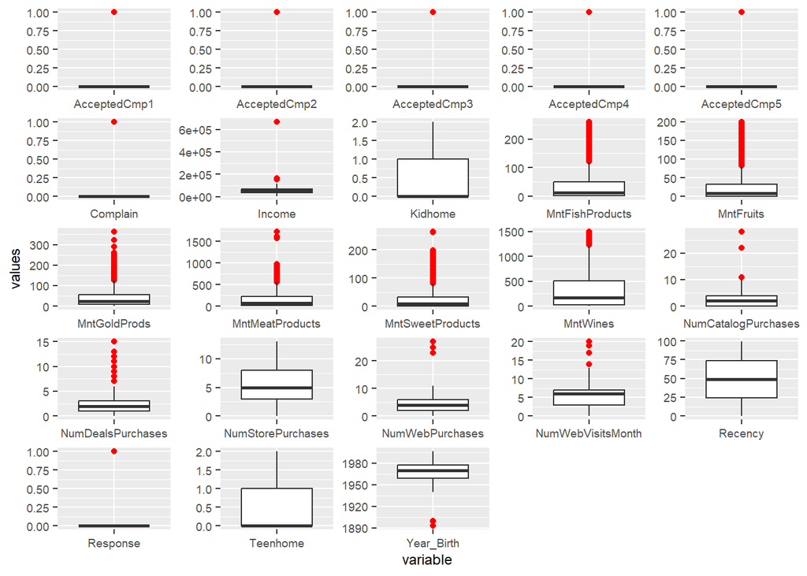

```r
df_num<-select_if(marketing_data,is.numeric)%>%select(-ID)
df_num_p<-df_num%>%gather(variable,values,1:23)
df_num_p%>%ggplot()+
  geom_boxplot(aes(x=variable,y=values), outlier.color="red") +
  facet_wrap(~variable,ncol=5,scales="free") +
  theme(strip.text.x = element_blank(),
        text = element_text(size=9))
```

##### Nhận xét - Dữ liệu trên cho thấy cột “Income” có số thu nhập đặt biệt rất cao. Điều này có thể do sai sót trong quá trình nhập dữ liệu. Ta sẽ loại bỏ các giá trị đó. - Để phân tích đưa ra cách gần chính xác nhất thì loại bỏ các giá trị ngoại lệ tránh làm ảnh hưởng đến dữ liệu

```r
remove_outliers <- function(x, na.rm = TRUE, ...) {
  qnt <- quantile(x, probs=c(.25, .75), na.rm = na.rm, ...)
  H <- 1.5 * IQR(x, na.rm = na.rm)
  y <- x
  y[x < (qnt[1] - H)] <- NA
  y[x > (qnt[2] + H)] <- NA
  y
}
marketing_data$Income <- remove_outliers(marketing_data$Income)
marketing_data$MntWines <- remove_outliers(marketing_data$MntWines)
marketing_data$MntFruits <- remove_outliers(marketing_data$MntFruits)
marketing_data$MntMeatProducts <- remove_outliers(marketing_data$MntMeatProducts)
marketing_data$MntFishProducts <- remove_outliers(marketing_data$MntFishProducts)
marketing_data$MntSweetProducts <- remove_outliers(marketing_data$MntSweetProducts)
marketing_data$MntGoldProds <- remove_outliers(marketing_data$MntGoldProds)
marketing_data$NumCatalogPurchases <- remove_outliers(marketing_data$NumCatalogPurchases)
marketing_data$NumWebPurchases <- remove_outliers(marketing_data$NumWebPurchases)
```